# B30_Superposition

| Abuzer Yakaryilmaz \| April 04, 2019 (updated) |
| --- |
| This cell contains some macros. If there is a problem with displaying mathematical formulas, please run this cell to load these macros. |

$ \newcommand{\bra}[1]{\langle #1|} $ $ \newcommand{\ket}[1]{|#1\rangle} $ $ \newcommand{\braket}[2]{\langle #1|#2\rangle} $ $ \newcommand{\dot}[2]{ #1 \cdot #2} $ $ \newcommand{\biginner}[2]{\left\langle #1,#2\right\rangle} $ $ \newcommand{\mymatrix}[2]{\left( \begin{array}{#1} #2\end{array} \right)} $ $ \newcommand{\myvector}[1]{\mymatrix{c}{#1}} $ $ \newcommand{\myrvector}[1]{\mymatrix{r}{#1}} $ $ \newcommand{\mypar}[1]{\left( #1 \right)} $ $ \newcommand{\mybigpar}[1]{ \Big( #1 \Big)} $ $ \newcommand{\sqrttwo}{\frac{1}{\sqrt{2}}} $ $ \newcommand{\dsqrttwo}{\dfrac{1}{\sqrt{2}}} $ $ \newcommand{\onehalf}{\frac{1}{2}} $ $ \newcommand{\donehalf}{\dfrac{1}{2}} $ $ \newcommand{\hadamard}{ \mymatrix{rr}{ \sqrttwo & \sqrttwo \\ \sqrttwo & -\sqrttwo }} $ $ \newcommand{\vzero}{\myvector{1\\0}} $ $ \newcommand{\vone}{\myvector{0\\1}} $ $ \newcommand{\vhadamardzero}{\myvector{ \sqrttwo \\ \sqrttwo } } $ $ \newcommand{\vhadamardone}{ \myrvector{ \sqrttwo \\ -\sqrttwo } } $ $ \newcommand{\myarray}[2]{ \begin{array}{#1}#2\end{array}} $ $ \newcommand{\X}{ \mymatrix{cc}{0 & 1 \\ 1 & 0} } $ $ \newcommand{\Z}{ \mymatrix{rr}{1 & 0 \\ 0 & -1} } $ $ \newcommand{\Htwo}{ \mymatrix{rrrr}{ \frac{1}{2} & \frac{1}{2} & \frac{1}{2} & \frac{1}{2} \\ \frac{1}{2} & -\frac{1}{2} & \frac{1}{2} & -\frac{1}{2} \\ \frac{1}{2} & \frac{1}{2} & -\frac{1}{2} & -\frac{1}{2} \\ \frac{1}{2} & -\frac{1}{2} & -\frac{1}{2} & \frac{1}{2} } } $ $ \newcommand{\CNOT}{ \mymatrix{cccc}{1 & 0 & 0 & 0 \\ 0 & 1 & 0 & 0 \\ 0 & 0 & 0 & 1 \\ 0 & 0 & 1 & 0} } $ $ \newcommand{\norm}[1]{ \left\lVert #1 \right\rVert } $

## Superposition

There is no classical counterpart of the concept "superposition".

But, we can still use a classical analogy that might help us to give some intuitions.

### Probability distribution

Suppose that Asja starts in $ \myvector{1\\0} $ and secretly applies the probabilistic operator $ \mymatrix{cc}{ 0.3 & 0.6 \\ 0.7 & 0.4 } $.

Because she applies her operator secretly, our information about her state is probabilistic, which is calculated as

$$ \myvector{0.3 \\ 0.7} = \mymatrix{cc}{ 0.3 & 0.6 \\ 0.7 & 0.4 } \myvector{1\\0}. $$

Asja is either in state 0 or in state 1.

However, from our point of view, Asja is in state 0 with probability $ 0.3 $ and in state 1 with probability $ 0.7 $.

We can say that Asja in a probability distribution of states 0 and 1, being in both states at the same time but with different weights.

On the other hand, if we observe Asja's state, then our information about Asja becomes deterministic: either $ \myvector{1 \\ 0} $ or $ \myvector{0 \\ 1} $.

We can say that, after observing Asja's state, the probabilistic state $ \myvector{0.3 \\ 0.7} $ collapses to either $ \myvector{1 \\ 0} $ or $ \myvector{0 \\ 1} $.

### The third experiment

Now, we can explain the following experiment.

[figure not shown]

**The initial Step**

The photon is in state $ \ket{v_0} = \vzero $.

**The first step**

Hadamard is applied:

$ \ket{v_1} = \hadamard \vzero = \vhadamardzero $.

At this point, the photon is in a **superposition** of state $ \ket{0} $ and state $ \ket{1} $, being in both states with the amplitudes $ \frac{1}{\sqrt{2}} $ and $ \frac{1}{\sqrt{2}} $, respectively.

The state of photon is $ \ket{v_1} = \vhadamardzero $, and we can also represent it also as follows: $ \ket{v_1} = \frac{1}{\sqrt{2}} \ket{0} + \frac{1}{\sqrt{2}} \ket{1} $.

**The second step**

Hadamard is applied again:

We write the effect of Hadamard on states $ \ket{0} $ and $ \ket{1} $ as follows:

$ H \ket{0} = \frac{1}{\sqrt{2}} \ket{0} + \frac{1}{\sqrt{2}} \ket{1} $

$ H \ket{1} = \frac{1}{\sqrt{2}} \ket{0} - \frac{1}{\sqrt{2}} \ket{1} $

This representation helps us to see clearly why the state $ \ket{1} $ disappears.

Now, let's see the effect of Hadamard on the quantum state $ \ket{v_1} = \frac{1}{\sqrt{2}} \ket{0} + \frac{1}{\sqrt{2}} \ket{1} $:

$ \ket{v_2} = H \ket{v_1} = H \mybigpar{ \frac{1}{\sqrt{2}} \ket{0} + \frac{1}{\sqrt{2}} \ket{1} } = \frac{1}{\sqrt{2}} H \ket{0} + \frac{1}{\sqrt{2}} H \ket{1} $

We can replace $ H\ket{0} $ and $ H\ket{1} $ as described above.

$ \ket{v_2} $ is formed by the summation of the following terms:

$ \frac{1}{\sqrt{2}} H \ket{0} = \frac{1}{2} \ket{0} + \frac{1}{2} \ket{1} $

$ \frac{1}{\sqrt{2}} H \ket{1} = \frac{1}{2} \ket{0} - \frac{1}{2} \ket{1} $

The amplitude of $ \ket{0} $ becomes 1, but the amplitude of $ \ket{1} $ becomes 0 because of cancellation.

$ \ket{v_2} = 1 \cdot \ket{0} + 0 \cdot \ket{1} = \ket{0} $.

The photon was in both states at the same time with certain amplitudes.

After the second Hadamard, the "outcomes" are interfered with each other.

The interference can be constructive or destructive.

In our examples, **the outcome $ \ket{0} $s are interfered constructively**, but **the outcome $ \ket{1} $s are interfered destructively**.

### Observations

Probabilistic systems: If there is a nonzero transition to a state, then it contributes to the probability of this state positively.

Quantum systems: If there is a nonzero transition to a state, then we cannot make such an interpretation without knowing the other transitions to this state.

If it is the only transition, then it contributes to the amplitude (and probability) of the state, and it does not matter whether the sign of the transition is positive or negative.

If there is more than one transition, then depending on the summation of all transitions, we can determine whether a specific transition contributes or not.

As a simple rule, if the final amplitude of the state and nonzero transition have the same sign, then it is a positive contribution; and, if they have the opposite signs, then it is a negative contribution.

### Task 1

[on paper]

Start in state $ \ket{u_0} = \ket{1} $.

Apply Hadamard operator to $ \ket{u_0} $, i.e, find $ \ket{u_1} = H \ket{u_0} $.

Apply Hadamard operator to $\ket{u_1}$, i.e, find $ \ket{u_2} = H \ket{u_1} $.

Observe the constructive and destructive interferences, when calculating $ \ket{u_2} $.

### Being in a superposition

A quantum system can be in more than one state with nonzero amplitudes.

Then, we say that our system is in a superposition of these states.

When evolving from a superposition, the resulting transitions may affect each other constructively and destructively.

This happens because of having opposite sign transition amplitudes.

Otherwise, all nonzero transitions are added up to each other as in probabilistic systems.

### Measurement

We can measure a quantum system, and then the system is observed in one of its states.

This is the most basic type of measurement in quantum computing.

(There are more generic measurement operators, but we will not mention about them.)

The probability of the system to be observed in a specified state is the square value of its amplitude.

- If the amplitude of a state is zero, then this state cannot be observed.
- If the amplitude of a state is nonzero, then this state can be observed.

For example, if the system is in quantum state

$$ \myrvector{ -\frac{\sqrt{2}}{\sqrt{3}} \\ \frac{1}{\sqrt{3}} }, $$

then, after a measurement, we can observe the system in state $\ket{0} $ with probability $ \frac{2}{3} $ and in state $\ket{1}$ with probability $ \frac{1}{3} $.

#### Collapsing

After the measurement, the system collapses to the observed state, and so the system is no longer in a superposition.

Thus, the information kept in a superposition is lost.

In the above example, when the system is observed in state $\ket{0}$, then the new state becomes $ \myvector{1 \\ 0} $.

If it is observed in state $\ket{1}$, then the new state becomes $ \myvector{0 \\ 1} $.

### Task 2 (Optional)

We have a quantum system with four states: $\ket{00}$, $ \ket{01} $, $\ket{10}$, and $ \ket{11} $.

We can also say that our system has two qubits.

Suppose that the system is in the following state:

$ \myrvector{ \dfrac{ 1 }{ \sqrt{3} - \sqrt{ 5 + 2\sqrt{6}} } \\ \\ \dfrac{1}{ \sqrt{3} - \sqrt{ 7 + 2\sqrt{12} } } \\ \\ \dfrac{ 1 }{ \sqrt{5} - \sqrt{ 13 + 2\sqrt{40} } } \\ \\ \dfrac{1}{ \sqrt{ 7 } - \sqrt{ 15 + 2 \sqrt{56} } } }. $

Find the probability of observing the system in state $\ket{00}$, $ \ket{01} $, $\ket{10}$, or $ \ket{11} $.

You may write a function to calculate the dominator of each fraction automatically, where its value is determined by three values $a$, $ b$, and $ c $ by assuming the form $ \sqrt{a} - \sqrt{b + 2 \sqrt{c} } $.

Verify that the total probability is 1 (or almost 1).

```python
#
# your solution is here
#

# Find expression to create the states
def expression(a, b, c):
    return (1/(a**(0.5) - (b + 2 * (c)**(0.5))**(0.5)))

# Construct the quantum state
quantum_state = [expression(3, 5, 6), expression(3, 7, 12), expression(5, 13, 40), expression(7, 15, 26)]

# Verify validity of the quantum state
# Square root of items must add up to 1 (comes from definition of quantum state)
# Each item correspons probability of observing the system in states |00>, |01>, |10>, |11>
print("The probability of observing the states 00, 01, 10, 11:")
prob = 0
for state in quantum_state:
    print("probability of current state " + str(state))
    prob += state ** 2


print("Verify validity of state - should be approximately 1: " + str(prob) )
```

```
The probability of observing the states 00, 01, 10, 11:
probability of current state -0.7071067811865476
probability of current state -0.5
probability of current state -0.3535533905932738
probability of current state -0.4212275914701778
Verify validity of state - should be approximately 1: 1.0524326838157672
```

click for our solution

### Z-gate (operator)

The indentity operator $ I = \mymatrix{cc}{1 & 0 \\ 0 & 1} $ does not affect the computation.

What about the following operator?

$ Z = \Z $.

It is very similar to the identity operator.

Consider the quantum state $ \ket{u} = \myvector{ \frac{3}{5} \\ \frac{4}{5} } $.

Let's calculate the new quantum state after applying $ Z $ to $ \ket{u} $:

$ \ket{u'} = Z \ket{u} = \Z \myvector{ \frac{3}{5} \\ \frac{4}{5} } = \myrvector{ \frac{3}{5} \\ -\frac{4}{5} } $.

The quantum states $ \ket{u} $ and $ \ket{u'} $ look similar.

The probabilities of observing state $\ket{0}$ and state $\ket{1}$ are the same when the system is in $ \ket{u} $ or $ \ket{u'} $.

On the other hand, they are far away from each other as shown below:

[figure not shown]

For example, by applying Hadamard to each of them, the probability of observing state $\ket{0}$ and state $\ket{1}$ may change.

To observe such an effect, we can do a simple experiment.

### Task 3

Create a quantum circuit with 5 qubits.

Apply h-gate (Hadamard operator) to each qubit.

Apply z-gate ($Z$ operator) to randomly picked qubits. (i.e., $ mycircuit.z(qreg[i]) $)

Apply h-gate to each qubit.

Measure each qubit.

Execute your program 1000 times.

Compare the outcomes of the qubits affected by z-gates, and the outcomes of the qubits not affected by z-gates.

Does z-gate change the outcome?

Why?

```python
# import all necessary objects and methods for quantum circuits
from qiskit import QuantumRegister, ClassicalRegister, QuantumCircuit, execute, Aer
# import randrange for random choices
from random import randrange

#
# your code is here
#
# Registers with 5 bits
qreg1 =  QuantumRegister(5)

# define a classical register with one bit
# it stores the measurement result of the quantum part
creg1 = ClassicalRegister(5)

# define our quantum circuit
mycircuit1 = QuantumCircuit(qreg1,creg1)

# store index of random z gates
z_gate_idx = []

# apply H gate to every bit
for i in range(5):
    mycircuit1.h(qreg1[i])
    if randrange(2) == 0: # 0.5 chance apply z gate
        mycircuit1.z(qreg1[i])
        z_gate_idx.append(i)
    # apply h gate again
    mycircuit1.h(qreg1[i])

# measure the first qubit, and store the result in the first classical bit
mycircuit1.measure(qreg1,creg1)

# get the numbers
job = execute(mycircuit1,Aer.get_backend('qasm_simulator'),shots=1000)
counts = job.result().get_counts(mycircuit1)
print(counts) # print the outcomes
print("z gate applied to: " + str(z_gate_idx))
# It can be seen that Z-gate changes value of the q-bit
```

```
{'00100': 1000}
z gate applied to: [2]
```

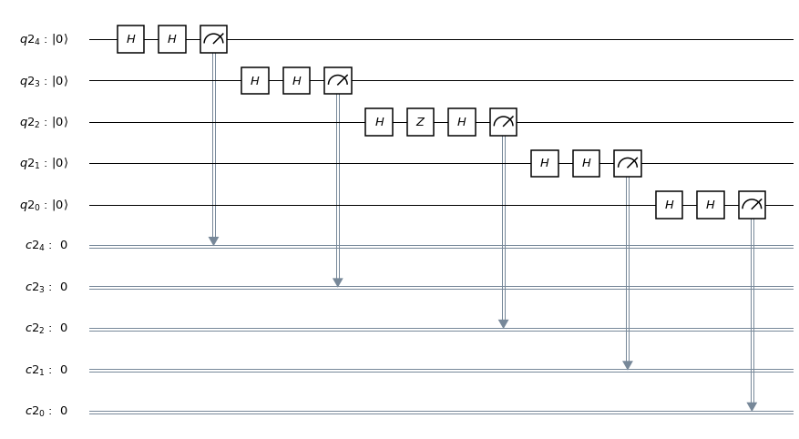

```python
# draw the circuit
mycircuit1.draw(output='mpl',reverse_bits=True)
# reexecute this cell if you DO NOT see the circuit diagram
```

click for our solution